# Show-case: properties visualized on the periodic table

Taha Ahmed

2025-05-25

```r
library(periodicdata)
source(here("vignettes/code/periodic-table-continuous-scale.R"), local = knit_global())
source(here("vignettes/code/periodic-table-discrete-scale.R"), local = knit_global())
source(here("vignettes/code/build-metadata.R"), local = knitr::knit_global())
```

This vignette is intended as a way to show-case the different ways this dataset can be visualized.

For starters, lets use the periodic table itself and visualize those properties that have varying “intensity” for each element.

## Visualizing continuous and discrete properties on the IUPAC table

Let’s look at the following selection of properties from this dataset:

```r
property_names
```

```
##  [1] "Melting_Point"           "Boiling_Point"           "Density"
##  [4] "Heat_of_Fusion"          "Heat_of_Vapourization"   "Thermal_Conductivity"
##  [7] "Density_Liquid"          "Molar_Volume"            "Electronegativity"
## [10] "Electron_Affinity"       "Electrical_Conductivity" "Percent_in_Universe"
## [13] "Percent_in_Sun"          "Percent_in_Meteorites"   "Percent_in_Earths_Crust"
## [16] "Percent_in_Oceans"       "Percent_in_Humans"       "Atomic_Radius"
## [19] "Covalent_Radius"         "Half_Life"               "Production_2010"
## [22] "Price_2010"              "Block"                   "Electrical_Type"
## [25] "Magnetic_Type"           "XKCD_Four_Elements"      "Natural_Occurrence"
```

We can use `typeof()` function to get the type of each property in `periodicdata` which is important separate continuous data plots from categorical data plots (I have not yet figured out a way to allow the same ggplot2 code generate both).

We will also include `Title` strings from the metadata into this tibble.

So if column type is either `double` or `integer` we can treat the scale as continuous, and if the type is `character` the scale needs to be discrete.

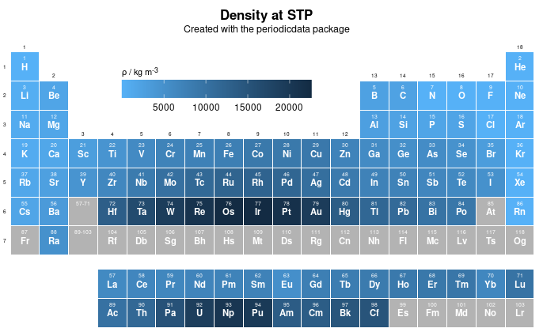

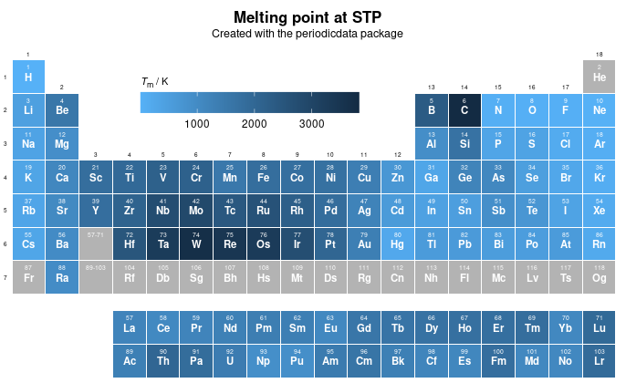

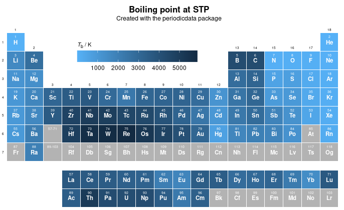

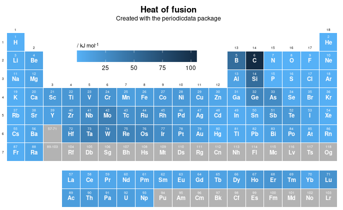

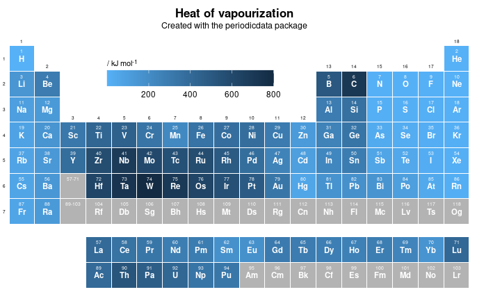

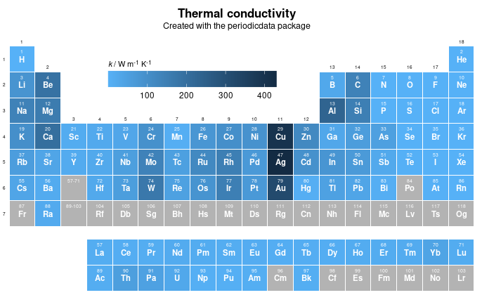

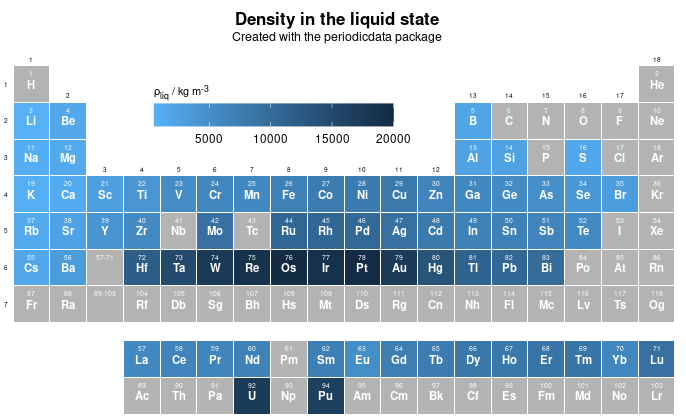

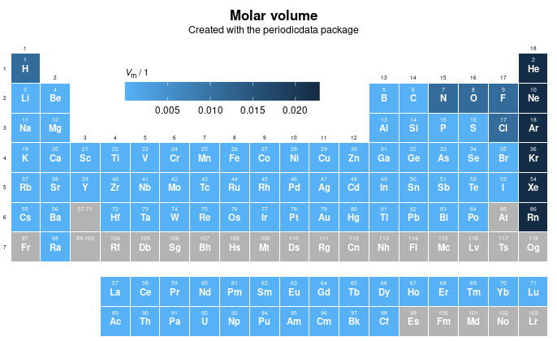

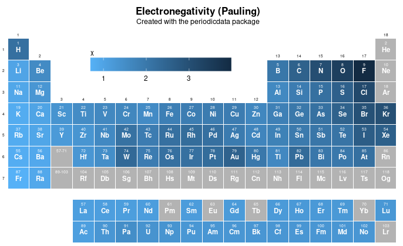

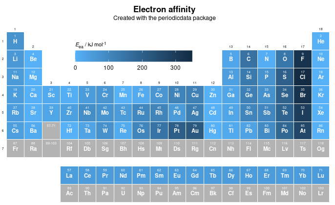

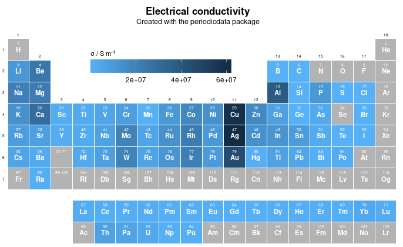

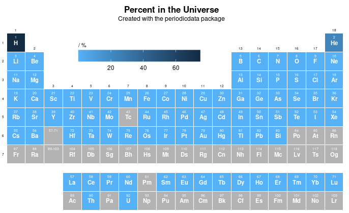

[10 more figures not shown]

[figure not shown]

[figure not shown]

[figure not shown]

[figure not shown]

[figure not shown]

```r
pmeta.continuous <- pmeta %>% filter(typeof %in% c("double", "integer"))
for (p in 1:dim(pmeta.continuous)[1]) {
   ptable.property <- pmeta.continuous$property[p]
   this.properties <- c(ptable.default.properties, ptable.property)
   periodicdata %>%
      # https://tidyselect.r-lib.org/reference/faq-external-vector.html
      select(all_of(this.properties)) %>%
      # now we must rename the ptable.property (the VALUE in the current plot) in order
      # for the plotting code to stay generic
      rename(VALUE = all_of(ptable.property)) %>%
      # adjust vertical position for La and Ac periods *before* changing type to character
      # https://stackoverflow.com/questions/22337394/dplyr-mutate-with-conditional-values
      mutate(Period = case_when(
         Series == "Lanthanide" ~ lanthanoids.vpos,
         Series == "Actinide" ~ actinoids.vpos,
         TRUE ~ Period)) %>%
      mutate(Atomic_Number = as.character(Atomic_Number)) %>%
      # create two virtual elements as placeholders for the lanthanoids/lanthanoids labels
      tibble::add_row(
         Name = c("lanthanoids", "actinoids"),
         Group = c(3, 3),
         Period = c(6, 7),
         Atomic_Number = c("57-71", "89-103"),
         Series = c("Lanthanide", "Actinide")) %>%
      periodic_plot_continuous(
         pdata = .,
         ptitle = pmeta.continuous$title[p],
         plegendtitle =
            # this is verbose but all in the service of good typography...
            # perhaps this should be extended to also hide unit if it's "1"?
            ifelse(
               pmeta.continuous$title_symbol[p] == "",
               ifelse(
                  pmeta.continuous$unit[p] == "",
                  "",
                  paste0("/ ", pmeta.continuous$unit[p])
               ),
               ifelse(
                  pmeta.continuous$unit[p] != "",
                  # use normal space before slash because symbols using Markdown
                  # or sub/supscripts get squished otherwise
                  paste0(pmeta.continuous$title_symbol[p], " / ", pmeta.continuous$unit[p]),
                  pmeta.continuous$title_symbol[p]
               )
            )
      ) %>%
      # since we are inside a loop we must explicitly print
      print()
}
```

## Other periodic table layouts

In the **left step periodic table**, aka Janet’s table, the table is congruent with the order in which electron shells are ideally filled according to the *aufbau* principle.

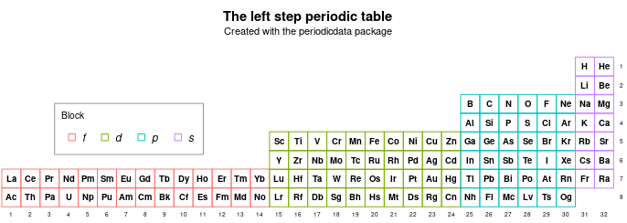

```r
symbol.voffset <- 0
x.offsets <- c(-1.2, 1.2)
# positive y offsets: first pushes bottom of table upwards, second pulls top of table upwards
y.offsets <- c(2, -2.3)
periodicdata %>%
   select(Symbol, Atomic_Number, Group_Left_Step, Period_Left_Step, Block) %>%
   mutate(Atomic_Number = as.character(Atomic_Number)) %>%
   # factorize Block to correspond to visual order
   mutate(Block = factor(Block, levels = c("f", "d", "p", "s"))) %>%
   { ggplot(.) +
      # AXES LIMITS AND BREAKS
      scale_x_continuous(
         breaks = seq(min(.$Group_Left_Step), max(.$Group_Left_Step)),
         limits = c(min(.$Group_Left_Step) + x.offsets[1], max(.$Group_Left_Step) + x.offsets[2]),
         expand = c(0, 0)) +
      scale_y_continuous(
         trans = "reverse",
         breaks = seq(min(.$Period_Left_Step), max(.$Period_Left_Step)),
         limits = c(max(.$Period_Left_Step) + y.offsets[1], min(.$Period_Left_Step) + y.offsets[2]),
         expand = c(0, 0)) +
      # ELEMENTS
      geom_point(
         size = 7, shape = 0,
         aes(y = Period_Left_Step, x = Group_Left_Step, colour = Block)) +
      # element symbol
      geom_text(size = 2.5, colour = "black", fontface = "bold",
         aes(label = Symbol, y = Period_Left_Step - symbol.voffset, x = Group_Left_Step)) +
      # LABELS
      geom_text(
         # https://stackoverflow.com/a/51388231/1198249
         data = . %>% distinct(Period_Left_Step, .keep_all = TRUE),
         x = 32.9, size = 1.7, colour = "black",
         aes(label = as.character(Period_Left_Step), y = Period_Left_Step)) +
      geom_text(
         data = . %>% filter(Period_Left_Step == 7),
         # I have no idea why or how negative y-coord makes sense, but nothing else worked
         y = -8.9, size = 1.7, colour = "black",
         aes(label = as.character(Group_Left_Step), x = Group_Left_Step)) +
      labs(
         title = "The left step periodic table",
         subtitle = "Created with the periodicdata package") +
      # force size of legend boxes independent of geom_point's aes
      guides(colour = guide_legend(
         override.aes = list(size = 2.25),
         ncol = 4, byrow = TRUE, title.hjust = 0)) +
      theme(
         panel.grid.major = element_blank(),
         panel.grid.minor = element_blank(),
         panel.background = element_rect(fill = "white"),
         plot.margin = unit(c(0, 0, -0.85, -0.85), "line"),
         axis.title = element_blank(),
         axis.text = element_blank(),
         axis.ticks = element_blank(),
         plot.title = element_text(
            face = "bold", size = rel(1.0), hjust = 0.5, vjust = -2,
            margin = margin(t = 0, r = 0, b = 0, l = 0, unit = "pt")),
         plot.subtitle = element_text(
            size = rel(0.75), hjust = 0.5, vjust = -4,
            margin = margin(t = 0, r = 0, b = 0, l = 0, unit = "pt")),
         legend.position = c(0.22, 0.38),
         legend.justification = c(0.5, 0),
         legend.direction = "horizontal",
         legend.title.position = "top",
         legend.title = element_text(size = rel(0.70)),
         # https://www.tidyverse.org/blog/2024/02/ggplot2-3-5-0-legends/#spacing-and-margins
         legend.text = element_text(face = "italic", margin = margin(l = 0, r = 2, unit = "pt")),
         legend.key = element_rect(fill = "transparent", colour = "transparent"),
         legend.background = element_rect(
            colour = "black", fill = "transparent", linewidth = 0.15)
      )
   }
```